# Synthesis — genus↔︎species reconciliation and metabolic interpretation

Anton

2026-05-31

```r
knitr::opts_knit$set(root.dir = rprojroot::find_rstudio_root_file())
knitr::opts_chunk$set(echo = TRUE, message = FALSE, warning = FALSE)
```

# Purpose

This document ties the two differential-abundance analyses (`week21.Rmd` genus, `week21_species.Rmd` species) together into the two pieces the report needs but neither single file delivers:

1. **Genus ↔︎ species reconciliation** — for each differential genus, does the signal resolve to a specific species, or dilute across several? (Operationalises the teacher’s guidance that a genus-level difference can be *more* reliable than the species-level one.)
2. **Metabolic interpretation** — maps the differential taxa onto well-established gut-microbial metabolic guilds (SCFA producers, mucin degraders, bile-acid metabolisers, …) to answer the project’s headline question: *which microbial metabolic activities differ between T2D and Healthy guts?*

Both levels are summarised with the **same single headline method** used as primary throughout the project: the **CLR-adjusted-for-Sex+Age linear model** (W21 §9). This is a synthesis layer, not a re-run of the full pipeline.

> **Scope note.** The reconciliation (taxonomy join) is a taught data operation. The metabolic-guild mapping is **literature-based interpretation, not a course method** — it is the curated-literature route flagged in the project plan, used because no reads/MAGs are available for PICRUSt2/FAPROTAX. Every guild assignment is sourced.

> **⚠️ Taxonomy-column fix (important).** The provided phyloseq objects have *ragged / shifted* taxonomy columns. In **both** the genus and species objects, the **`Species`** column carries the finest-resolved name (a binomial like `s__Escherichia coli`, a genus like `s__Roseburia`, or a family bin like `s__Bacteroidaceae`), while the **`Genus`** column is unreliable — for many lineages (e.g. Clostridia, Lactobacillales) it holds the **family** (`g__Lachnospiraceae`, `g__Ruminococcaceae`), not the genus, and `Family` then holds the order. The shift is *inconsistent* (Proteobacteria like Escherichia are correctly aligned; Clostridia are shifted up one), so a fixed column choice fails. The robust rule, used throughout this file: **take the finest label from `Species` (falling back to `Genus` only when `Species` is empty), and derive the genus as its first token.** Labelling genus results with the raw `Genus` column gives *families* (`Lachnospiraceae`) instead of genera (`Roseburia`, `Faecalibacterium`) and silently breaks any genus-keyed interpretation.

# 1. Libraries

```r
library(phyloseq)
library(dplyr)
library(tibble)
library(tidyr)
library(stringr)
library(ggplot2)
library(broom)
```

# 2. Load both levels (Chinese cohort)

```r
load("project/data/D003924_Diabetes_Mellitus,_T/genus/phyloseq.RData")
ps_genus <- subset_samples(pylsq, Project.ID == "PRJNA422434")
rm(pylsq)

load("project/data/D003924_Diabetes_Mellitus,_T/species/phyloseq.RData")
ps_species <- subset_samples(pylsq, Project.ID == "PRJNA422434")
rm(pylsq)

ps_genus
```

```
## phyloseq-class experiment-level object
## otu_table()   OTU Table:         [ 58 taxa and 359 samples ]
## sample_data() Sample Data:       [ 359 samples by 12 sample variables ]
## tax_table()   Taxonomy Table:    [ 58 taxa by 7 taxonomic ranks ]
## phy_tree()    Phylogenetic Tree: [ 58 tips and 27 internal nodes ]
```

```r
ps_species
```

```
## phyloseq-class experiment-level object
## otu_table()   OTU Table:         [ 173 taxa and 359 samples ]
## sample_data() Sample Data:       [ 359 samples by 12 sample variables ]
## tax_table()   Taxonomy Table:    [ 173 taxa by 7 taxonomic ranks ]
## phy_tree()    Phylogenetic Tree: [ 173 tips and 59 internal nodes ]
```

> *Taught in: W20-01 (load phyloseq), W20-03 (`subset_samples`). Cohort filter rationale: `cohort_rationale.Rmd`.*

# 3. Headline method at both levels (CLR adjusted for Sex + Age)

```r
# Run the primary CLR-adjusted-for-Sex+Age per-taxon model and return tidy results.
# Identical model to week21.Rmd §9 / week21_species.Rmd, applied at one level.
# Also derives a CORRECTED genus_key (see taxonomy-column fix in the header).
run_clr_da <- function(ps, level_label) {
  ps_clr <- transform_sample_counts(ps, function(x) {
    x <- x + 1e-9
    log(x) - mean(log(x))
  })
  otu_clr  <- as(otu_table(ps_clr), "matrix") %>% t() %>% as.data.frame()
  meta_clr <- data.frame(sample_data(ps_clr))
  tax_clr  <- as(tax_table(ps_clr), "matrix") %>% as.data.frame()

  res <- otu_clr %>%
    rownames_to_column("sample_id") %>%
    pivot_longer(-sample_id, names_to = "taxon", values_to = "clr") %>%
    left_join(meta_clr %>% rownames_to_column("sample_id"), by = "sample_id") %>%
    left_join(tax_clr  %>% rownames_to_column("taxon"),     by = "taxon") %>%
    mutate(
      Disease.MESH.ID = factor(Disease.MESH.ID, levels = c("D006262", "D003924")),
      Sex             = factor(Sex,             levels = c("Female", "Male")),
      Host.age        = as.numeric(Host.age)
    ) %>%
    group_by(taxon, Genus, Species) %>%
    group_modify(~ broom::tidy(lm(clr ~ Disease.MESH.ID + Sex + Host.age, data = .x))) %>%
    ungroup() %>%
    filter(term == "Disease.MESH.IDD003924") %>%
    mutate(
      q_value = p.adjust(p.value, method = "BH"),
      level   = level_label,
      direction = case_when(
        q_value < 0.05 & estimate > 0 ~ "T2D-enriched",
        q_value < 0.05 & estimate < 0 ~ "T2D-depleted",
        TRUE                          ~ "n.s."
      )
    )

  # ---- Corrected labels (both objects have ragged/shifted taxonomy) ----
  # In BOTH the genus and species objects the `Species` column carries the
  # finest-resolved name (a binomial, a genus, or a family bin), while the
  # `Genus` column is unreliable (often the family). So we take the finest
  # label from `Species` (falling back to `Genus` only when `Species` is empty)
  # and derive the genus as its first token.
  empty <- function(x) is.na(x) | x %in% c("", "s__", "g__")
  res$taxon_label <- sub("^[a-z]__", "", ifelse(empty(res$Species), res$Genus, res$Species))
  res$genus_key   <- sub(" .*$", "", res$taxon_label)   # first token = genus
  res
}

clr_genus   <- run_clr_da(ps_genus,   "Genus")
clr_species <- run_clr_da(ps_species, "Species")
```

> *Taught in: W21 reference Rmd §9 (`lm(clr ~ group + covariates)` per taxon, BH-adjusted). CLR closure §9; covariate adjustment Alberdi reading §5; BH/FDR §6. The `genus_key` derivation is the taxonomy-column fix described in the header.*

## 3a. The differential genera (corrected labels)

```r
clr_genus %>%
  filter(q_value < 0.05) %>%
  transmute(genus = taxon_label,
            family = sub("^g__", "", Genus),
            estimate = round(estimate, 2),
            q_value  = signif(q_value, 3),
            direction) %>%
  arrange(estimate)
```

```
## # A tibble: 4 × 5
##   genus            family           estimate q_value direction
##   <chr>            <chr>               <dbl>   <dbl> <chr>
## 1 Roseburia        Lachnospiraceae     -3.75 0.00878 T2D-depleted
## 2 Faecalibacterium Ruminococcaceae     -3.05 0.0177  T2D-depleted
## 3 Lactobacillus    Lactobacillaceae     1.51 0.0456  T2D-enriched
## 4 Megasphaera      Veillonellaceae      2.08 0.0264  T2D-enriched
```

# 4. Genus ↔︎ species reconciliation

The reconciliation key is the **corrected real-genus label** (`genus_key`) at both levels. For each genus that is **significant at genus level**, we list the species sharing that genus and ask whether they agree in direction and which (if any) clears FDR.

```r
clr_genus_k   <- clr_genus   %>% filter(!is.na(genus_key), genus_key != "")
clr_species_k <- clr_species %>% filter(!is.na(genus_key), genus_key != "")

sig_genera <- clr_genus_k %>%
  filter(q_value < 0.05) %>%
  transmute(genus_key,
            genus_label    = taxon_label,
            genus_estimate = estimate,
            genus_q        = q_value,
            genus_dir      = direction)

reconciliation <- sig_genera %>%
  left_join(
    clr_species_k %>%
      select(genus_key, sp_label = taxon_label, Species,
             sp_estimate = estimate, sp_q = q_value, sp_dir = direction),
    by = "genus_key"
  ) %>%
  group_by(genus_label, genus_estimate, genus_q, genus_dir) %>%
  summarise(
    n_species         = sum(!is.na(Species)),
    n_species_sig     = sum(sp_q < 0.05, na.rm = TRUE),
    n_agree_direction = sum(sign(sp_estimate) == sign(genus_estimate), na.rm = TRUE),
    top_species       = sp_label[which.max(abs(replace(sp_estimate, is.na(sp_estimate), 0)))][1],
    resolution = case_when(
      sum(!is.na(Species)) == 0           ~ "no species mapped",
      sum(sp_q < 0.05, na.rm = TRUE) >= 1  ~ "resolves to species",
      TRUE                                 ~ "diluted across species"
    ),
    .groups = "drop"
  ) %>%
  arrange(genus_q)

reconciliation
```

```
## # A tibble: 4 × 9
##   genus_label      genus_estimate genus_q genus_dir    n_species n_species_sig
##   <chr>                     <dbl>   <dbl> <chr>            <int>         <int>
## 1 Roseburia                 -3.75 0.00878 T2D-depleted         3             1
## 2 Faecalibacterium          -3.05 0.0177  T2D-depleted         1             0
## 3 Megasphaera                2.08 0.0264  T2D-enriched         0             0
## 4 Lactobacillus              1.51 0.0456  T2D-enriched        14             0
## # ℹ 3 more variables: n_agree_direction <int>, top_species <chr>,
## #   resolution <chr>
```

Interpretation of `resolution`:

- **resolves to species** — at least one species in the genus is itself FDR-significant, so the genus signal has a named species driver (report that species).
- **diluted across species** — the genus is significant but no single species clears FDR; the effect is spread across several low-prevalence species. *Per the teacher’s guidance, the genus result is reported as the reliable finding here.*
- **no species mapped** — no species-level counterpart in the resolved panel.

> *Taught in: data join / `tax_glom`-style aggregation logic (W20-01). The reconciliation rule itself is project synthesis.*

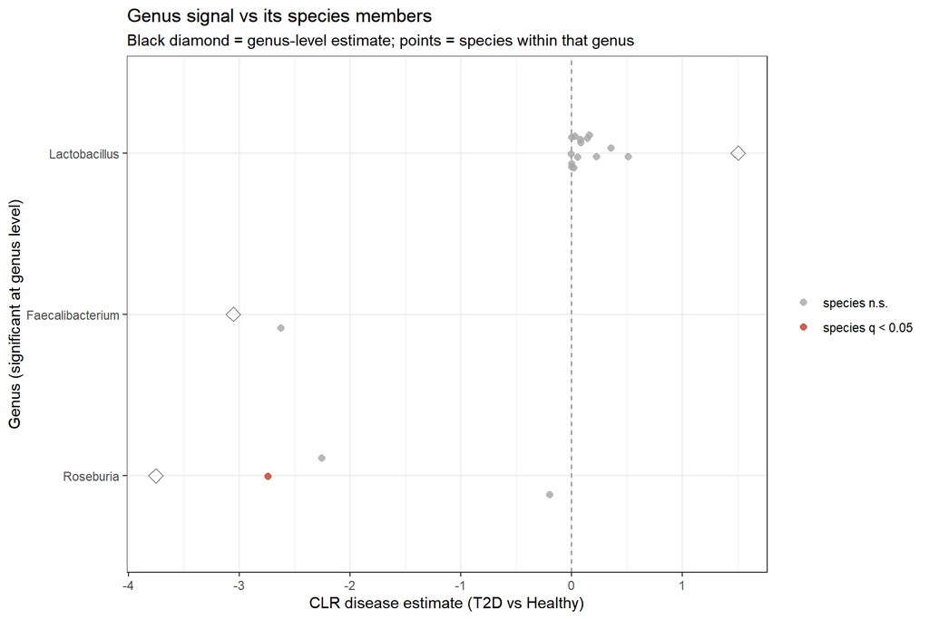

```r
recon_long <- sig_genera %>%
  inner_join(clr_species_k %>% select(genus_key, sp_estimate = estimate, sp_q = q_value),
             by = "genus_key") %>%
  mutate(
    genus_label = reorder(genus_label, genus_estimate),
    sp_sig      = ifelse(sp_q < 0.05, "species q < 0.05", "species n.s.")
  )

ggplot(recon_long, aes(x = sp_estimate, y = genus_label)) +
  geom_vline(xintercept = 0, linetype = "dashed", colour = "grey50") +
  geom_point(aes(x = genus_estimate), shape = 5, size = 3, colour = "black") +
  geom_jitter(aes(colour = sp_sig), height = 0.15, width = 0, alpha = 0.8, size = 2) +
  scale_colour_manual(values = c("species q < 0.05" = "#C0392B",
                                 "species n.s."      = "grey65")) +
  labs(x = "CLR disease estimate (T2D vs Healthy)",
       y = "Genus (significant at genus level)",
       colour = NULL,
       title = "Genus signal vs its species members",
       subtitle = "Black diamond = genus-level estimate; points = species within that genus") +
  theme_bw()
```

# 5. Metabolic interpretation (literature-based)

The curated guild lookup below assigns each gut genus to a **metabolic guild** with a sourced functional role, then joins it to the differential genera (`genus_key`).

```r
guilds <- tribble(
  ~genus_key,             ~guild,                          ~metabolic_role,
  "Faecalibacterium",     "Butyrate / SCFA producer",      "Major butyrate producer; anti-inflammatory (F. prausnitzii)",
  "Roseburia",            "Butyrate / SCFA producer",      "Butyrate from dietary fibre",
  "Eubacterium",          "Butyrate / SCFA producer",      "Butyrate; some bile-acid transformation",
  "Coprococcus",          "Butyrate / SCFA producer",      "Butyrate producer",
  "Anaerostipes",         "Butyrate / SCFA producer",      "Lactate-utilising butyrate producer",
  "Subdoligranulum",      "Butyrate / SCFA producer",      "Butyrate producer",
  "Butyrivibrio",         "Butyrate / SCFA producer",      "Butyrate producer",
  "Oscillibacter",        "Butyrate / SCFA producer",      "Butyrate/valerate producer",
  "Flavonifractor",       "Butyrate / SCFA producer",      "Butyrate; flavonoid degradation",
  "Blautia",              "Acetate / SCFA producer",       "Acetate; H2 utilisation",
  "Dorea",                "Acetate / SCFA producer",       "SCFA / H2 metabolism",
  "Akkermansia",          "Mucin degrader",                "Mucin degradation; gut-barrier & metabolic health",
  "Bacteroides",          "Polysaccharide fermenter",      "Broad glycan degradation; propionate; bile acids",
  "Parabacteroides",      "Polysaccharide fermenter",      "Propionate; bile-acid metabolism",
  "Prevotella",           "Fibre / plant-glycan fermenter","Complex plant polysaccharide fermentation",
  "Alistipes",            "Bile-acid metaboliser",         "Bile-tolerant; propionate",
  "Bifidobacterium",      "Lactate / acetate producer",    "Acetate/lactate; metformin-responsive; probiotic",
  "Collinsella",          "Lactate / acetate producer",    "Actinobacterial fermenter; linked to host lipid metabolism",
  "Lactobacillus",        "Lactate producer",              "Lactate; often increased in T2D",
  "Weissella",            "Lactate producer",              "Lactic-acid bacterium",
  "Enterococcus",         "Lactate producer",              "Lactic-acid bacterium; facultative",
  "Streptococcus",        "Lactate producer (oral-origin)","Lactate; oral-origin; increased in T2D",
  "Veillonella",          "Lactate utiliser -> propionate","Converts lactate to propionate",
  "Megasphaera",          "Lactate utiliser -> SCFA",      "Lactate-utiliser; propionate/butyrate via acrylate pathway",
  "Dialister",            "Propionate producer",           "Propionate via succinate pathway",
  "Phascolarctobacterium","Propionate producer",           "Succinate-utilising propionate producer",
  "Mitsuokella",          "Propionate / SCFA producer",    "Succinate/propionate; carbohydrate fermenter",
  "Escherichia",          "Facultative / pro-inflammatory","LPS; facultative anaerobe; metformin-associated",
  "Klebsiella",           "Facultative / pro-inflammatory","Facultative; pro-inflammatory",
  "Lachnoclostridium",    "Bile-acid metaboliser",         "Clostridium-clade; bile-acid 7a-dehydroxylation (variable)",
  "Clostridium",          "Bile-acid metaboliser",         "Bile-acid transformation (variable)",
  "Ruminococcus",         "Resistant-starch degrader",     "Resistant starch / fibre degradation",
  "Bilophila",            "Sulfite reducer / bile",        "Bile-driven sulfite reduction; H2S",
  "Desulfovibrio",        "Sulfate reducer",               "H2S production; mucosal",
  "Fusobacterium",        "Facultative / pro-inflammatory","Mucosa-associated; pro-inflammatory",
  "Haemophilus",          "Facultative (oral-origin)",     "Facultative anaerobe; oral-origin"
)

guilds
```

```
## # A tibble: 36 × 3
##    genus_key        guild                    metabolic_role
##    <chr>            <chr>                    <chr>
##  1 Faecalibacterium Butyrate / SCFA producer Major butyrate producer; anti-infl…
##  2 Roseburia        Butyrate / SCFA producer Butyrate from dietary fibre
##  3 Eubacterium      Butyrate / SCFA producer Butyrate; some bile-acid transform…
##  4 Coprococcus      Butyrate / SCFA producer Butyrate producer
##  5 Anaerostipes     Butyrate / SCFA producer Lactate-utilising butyrate producer
##  6 Subdoligranulum  Butyrate / SCFA producer Butyrate producer
##  7 Butyrivibrio     Butyrate / SCFA producer Butyrate producer
##  8 Oscillibacter    Butyrate / SCFA producer Butyrate/valerate producer
##  9 Flavonifractor   Butyrate / SCFA producer Butyrate; flavonoid degradation
## 10 Blautia          Acetate / SCFA producer  Acetate; H2 utilisation
## # ℹ 26 more rows
```

> *Literature-based interpretation, NOT a course method. Key sources: Qin et al. 2012 (Nature, T2D MGWAS — butyrate-producer depletion, opportunist increase); Karlsson et al. 2013 (Nature, T2D in European women); Forslund et al. 2015 (Nature, metformin confounding); Sokol et al. 2008 (F. prausnitzii anti-inflammatory); Everard et al. 2013 & Dao et al. 2016 (Akkermansia & metabolic health); Louis & Flint 2017 (gut butyrate producers); Reichardt et al. 2014 / Koh et al. 2016 (SCFA pathways & propionate producers).*

## 5a. Differential genera with their metabolic guild

```r
genus_metabolic <- clr_genus_k %>%
  filter(q_value < 0.05) %>%
  left_join(guilds, by = "genus_key") %>%
  mutate(guild = ifelse(is.na(guild), "Unassigned (no curated role)", guild)) %>%
  select(genus = taxon_label, direction, estimate, q_value, guild, metabolic_role) %>%
  arrange(direction, estimate)

genus_metabolic
```

```
## # A tibble: 4 × 6
##   genus            direction    estimate q_value guild            metabolic_role
##   <chr>            <chr>           <dbl>   <dbl> <chr>            <chr>
## 1 Roseburia        T2D-depleted    -3.75 0.00878 Butyrate / SCFA… Butyrate from…
## 2 Faecalibacterium T2D-depleted    -3.05 0.0177  Butyrate / SCFA… Major butyrat…
## 3 Lactobacillus    T2D-enriched     1.51 0.0456  Lactate producer Lactate; ofte…
## 4 Megasphaera      T2D-enriched     2.08 0.0264  Lactate utilise… Lactate-utili…
```

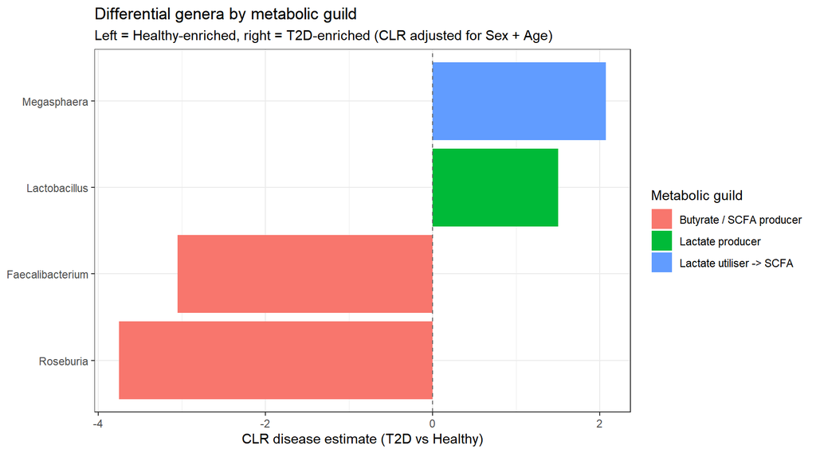

```r
genus_metabolic %>%
  mutate(genus = reorder(genus, estimate)) %>%
  ggplot(aes(x = estimate, y = genus, fill = guild)) +
  geom_col() +
  geom_vline(xintercept = 0, linetype = "dashed", colour = "grey40") +
  labs(x = "CLR disease estimate (T2D vs Healthy)",
       y = NULL, fill = "Metabolic guild",
       title = "Differential genera by metabolic guild",
       subtitle = "Left = Healthy-enriched, right = T2D-enriched (CLR adjusted for Sex + Age)") +
  theme_bw()
```

## 5b. Guild-level summary

```r
guild_summary <- genus_metabolic %>%
  group_by(guild, direction) %>%
  summarise(n_genera = n(),
            genera = paste(genus, collapse = ", "),
            .groups = "drop") %>%
  arrange(direction, desc(n_genera))

guild_summary
```

```
## # A tibble: 3 × 4
##   guild                    direction    n_genera genera
##   <chr>                    <chr>           <int> <chr>
## 1 Butyrate / SCFA producer T2D-depleted        2 Roseburia, Faecalibacterium
## 2 Lactate producer         T2D-enriched        1 Lactobacillus
## 3 Lactate utiliser -> SCFA T2D-enriched        1 Megasphaera
```

# 6. Answering the headline question

With the corrected labels, the genus-level result is a clean, literature-consistent metabolic signature:

- **Healthy-enriched:** **butyrate producers** *Roseburia* and *Faecalibacterium* — the two flagship SCFA producers of the gut. Their depletion in T2D is the single most reproducible functional signature in the literature (Qin 2012; Karlsson 2013). Butyrate fuels colonocytes and is anti-inflammatory, so reduced butyrate-producing capacity is mechanistically tied to gut-barrier and metabolic dysfunction.
- **T2D-enriched:** **lactate producers / lactate-utilising taxa** (*Lactobacillus*, *Megasphaera*). *Lactobacillus* enrichment in T2D is reported repeatedly (Qin 2012; Karlsson 2013) and is also **metformin-responsive**, so the alpha-diversity caveat (`alpha_diversity.Rmd` §10) applies — drug status is unmeasured (Forslund 2015).

**Report sentence (fill numbers from §3a / §5):**

> *“After adjusting for sex and age within the Chinese cohort, four genera were differentially abundant (CLR, q < 0.05): the butyrate producers Roseburia and Faecalibacterium were depleted in T2D, while the lactate-associated genera Lactobacillus and Megasphaera were enriched. This reproduces the canonical T2D functional signature — loss of SCFA-producing capacity — at the level our data support (taxonomy → curated function), without claiming gene-level evidence.”*

Three honesty rails for the exam:

1. This is **taxonomy → inferred function**, not measured function — no MAGs/genes, so PICRUSt2/FAPROTAX were not possible; the guild table is curated and cited.
2. Guilds are assigned at **genus** level using the corrected label; unresolved family-level bins (genus object `Species` = `s__Bacteroidaceae`, etc.) carry no guild.
3. The **metformin confound** (Forslund 2015) is the standing limitation on any T2D-enriched functional claim.

# 7. Save outputs

```r
#saveRDS(reconciliation,   "project/results/genus_species_reconciliation.rds")
#saveRDS(genus_metabolic,  "project/results/genus_metabolic_guilds.rds")
#saveRDS(guild_summary,    "project/results/guild_summary.rds")
```

> *Housekeeping (`saveRDS`) — not a course method; persists the synthesis tables for the report.*